# Estimation-of-Daily-Bicycle-Traffic-Using-Machine-and-Deep-Learning-Techniques

## Using XGBoost's Variable Importances to do Dimensionality Reduction Followed by SNN

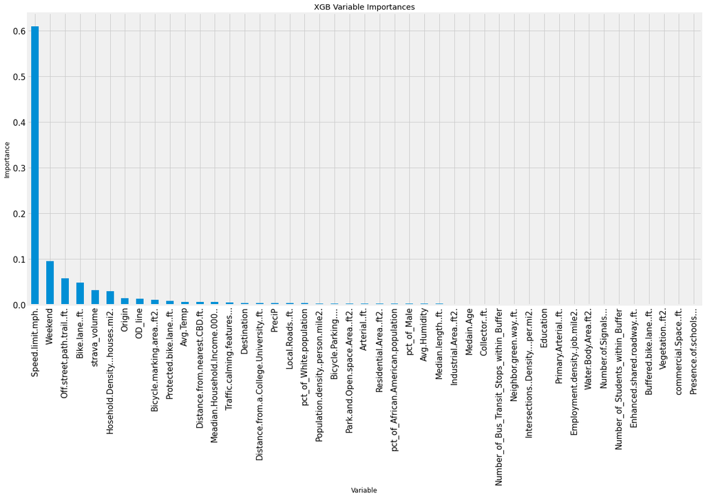

```python
XGB_feature_importances_df = pd.DataFrame(xgb_final.feature_importances_, index=X_data.columns, columns=[
                                          'Importance']).sort_values('Importance', ascending=False)
XGB_feature_importances_df.plot(kind='bar', figsize=(20, 10), style='fivethirtyeight', fontsize=15,
                                legend=False, title="XGB Variable Importances", ylabel="Importance", xlabel="Variable")
```

```python
XGB_feature_importances_df
```

|  | Importance |
| --- | --- |
| Speed.limit.mph. | 0.608755 |
| Weekend | 0.094919 |
| Off.street.path.trail..ft. | 0.058005 |
| Bike.lane..ft. | 0.048166 |
| strava_volume | 0.032466 |
| Hosehold.Density...houses.mi2. | 0.029132 |
| Origin | 0.014043 |
| OD_line | 0.013440 |
| Bicycle.marking.area..ft2. | 0.011127 |
| Protected.bike.lane..ft. | 0.008068 |
| Avg.Temp | 0.005864 |
| Distance.from.nearest.CBD.ft. | 0.005792 |
| Meadian.Household.Income.000.. | 0.005709 |
| Traffic.calming.features... | 0.004963 |
| Destination | 0.004245 |
| Distance.from.a.College.University..ft. | 0.003758 |
| PreciP | 0.003730 |
| Local.Roads..ft. | 0.003371 |
| pct_of_White.population | 0.003262 |
| Population.density..person.mile2. | 0.003107 |
| Bicycle.Parking.... | 0.002841 |
| Park.and.Open.space.Area..ft2. | 0.002773 |
| Arterial..ft. | 0.002684 |
| Residential.Area..ft2. | 0.002553 |
| pct_of_African.American.population | 0.002222 |
| pct_of_Male | 0.002156 |
| Avg.Humidity | 0.002144 |
| Median.length..ft. | 0.002060 |
| Industrial.Area..ft2. | 0.001864 |
| Medain.Age | 0.001859 |
| Collector..ft. | 0.001855 |
| Number_of_Bus_Transit_Stops_within_Buffer | 0.001828 |
| Neighbor.green.way..ft. | 0.001684 |
| Intersections..Density....per.mi2. | 0.001553 |
| Education | 0.001471 |
| Primary.Arterial..ft. | 0.001308 |
| Employment.density..job.mile2. | 0.000977 |
| Water.Body.Area.ft2. | 0.000955 |
| Number.of.Signals... | 0.000841 |
| Number_of_Students_within_Buffer | 0.000771 |
| Enhanced.shared.roadway..ft. | 0.000742 |
| Buffered.bike.lane..ft. | 0.000579 |
| Vegetation..ft2. | 0.000353 |
| commercial.Space..ft. | 0.000005 |
| Presence.of.schools... | 0.000002 |

```python
# get dataframe of XGB variable importances > 0.00
XGB_gt_0_importances_df = XGB_feature_importances_df.loc[
    XGB_feature_importances_df.Importance > 0.00]
XGB_gt_0_importances_df = X_data[XGB_gt_0_importances_df.index]
XGB_gt_0_importances_df = pd.concat([XGB_gt_0_importances_df, Y_data], axis=1)
XGB_gt_0_importances_df
```

|  | Speed.limit.mph. | Weekend | Off.street.path.trail..ft. | Bike.lane..ft. | strava_volume | Hosehold.Density...houses.mi2. | Origin | OD_line | Bicycle.marking.area..ft2. | Protected.bike.lane..ft. | ... | Employment.density..job.mile2. | Water.Body.Area.ft2. | Number.of.Signals... | Number_of_Students_within_Buffer | Enhanced.shared.roadway..ft. | Buffered.bike.lane..ft. | Vegetation..ft2. | commercial.Space..ft. | Presence.of.schools... | DailyVolume |
| --- | --- | --- | --- | --- | --- | --- | --- | --- | --- | --- | --- | --- | --- | --- | --- | --- | --- | --- | --- | --- | --- |
| 0 | 28.12500 | 0 | 7812.380096 | 1926.701848 | 40 | 62276.54698 | 0 | 23.0 | 237.573372 | 533.142155 | ... | 188153.807 | 1624098.658 | 3 | 1418 | 0.0 | 0.000000 | 190209.5112 | 0.0 | 0 | 331 |
| 1 | 28.12500 | 0 | 7812.380096 | 1926.701848 | 75 | 62276.54698 | 0 | 37.0 | 237.573372 | 533.142155 | ... | 188153.807 | 1624098.658 | 3 | 1418 | 0.0 | 0.000000 | 190209.5112 | 0.0 | 0 | 972 |
| 2 | 28.12500 | 0 | 7812.380096 | 1926.701848 | 85 | 62276.54698 | 0 | 23.0 | 237.573372 | 533.142155 | ... | 188153.807 | 1624098.658 | 3 | 1418 | 0.0 | 0.000000 | 190209.5112 | 0.0 | 0 | 846 |
| 3 | 28.12500 | 0 | 7812.380096 | 1926.701848 | 80 | 62276.54698 | 0 | 32.0 | 237.573372 | 533.142155 | ... | 188153.807 | 1624098.658 | 3 | 1418 | 0.0 | 0.000000 | 190209.5112 | 0.0 | 0 | 914 |
| 4 | 28.12500 | 1 | 7812.380096 | 1926.701848 | 15 | 62276.54698 | 0 | 19.0 | 237.573372 | 533.142155 | ... | 188153.807 | 1624098.658 | 3 | 1418 | 0.0 | 0.000000 | 190209.5112 | 0.0 | 0 | 390 |
| ... | ... | ... | ... | ... | ... | ... | ... | ... | ... | ... | ... | ... | ... | ... | ... | ... | ... | ... | ... | ... | ... |
| 1074 | 21.22807 | 0 | 7258.123400 | 0.000000 | 95 | 49503.43774 | 0 | 0.0 | 472.376215 | 0.000000 | ... | 196587.726 | 0.000 | 1 | 982 | 0.0 | 622.878954 | 229204.0629 | 0.0 | 0 | 323 |
| 1075 | 21.22807 | 0 | 7258.123400 | 0.000000 | 145 | 49503.43774 | 0 | 0.0 | 472.376215 | 0.000000 | ... | 196587.726 | 0.000 | 1 | 982 | 0.0 | 622.878954 | 229204.0629 | 0.0 | 0 | 452 |
| 1076 | 21.22807 | 0 | 7258.123400 | 0.000000 | 130 | 49503.43774 | 0 | 0.0 | 472.376215 | 0.000000 | ... | 196587.726 | 0.000 | 1 | 982 | 0.0 | 622.878954 | 229204.0629 | 0.0 | 0 | 319 |
| 1077 | 21.22807 | 0 | 7258.123400 | 0.000000 | 65 | 49503.43774 | 0 | 0.0 | 472.376215 | 0.000000 | ... | 196587.726 | 0.000 | 1 | 982 | 0.0 | 622.878954 | 229204.0629 | 0.0 | 0 | 324 |
| 1078 | 21.22807 | 0 | 7258.123400 | 0.000000 | 135 | 49503.43774 | 0 | 0.0 | 472.376215 | 0.000000 | ... | 196587.726 | 0.000 | 1 | 982 | 0.0 | 622.878954 | 229204.0629 | 0.0 | 0 | 338 |

6746 rows × 46 columns

After feeding the XGBoosts important features through the brute-force SNN loop (found in a separate notebook), here are the hyperparameters we received:

```
Hidden Layer Neurons = 823
HL Activation Function = 'relu'
Output Layer Activation Function = 'linear'
Learning Rate = 0.001
```

```python
metrics = [RootMeanSquaredError(), "mean_absolute_percentage_error",
           "mean_absolute_error"]

num_folds = 10
kfold = KFold(n_splits=10, shuffle=True, random_state=1)

# Now we perform KFold after using XGBoost for Dimensionality Reduction:

fold_num = 1
XGB_MAPE_train = []
XGB_MAPE_scores = []
XGB_RMSE_train = []
XGB_RMSE_scores = []
XGB_MAE_train = []
XGB_MAE_scores = []
XGB_R2_train = []
XGB_R2_scores = []

XGB_Y_data = np.asarray(XGB_gt_0_importances_df['DailyVolume'])
XGB_X_data = np.asarray(XGB_gt_0_importances_df.drop('DailyVolume', axis=1))

for train, test in kfold.split(XGB_X_data, XGB_Y_data):
    # now our data is ready to go into our model.
    model = Sequential([
        Dense(823, activation='relu', input_shape=(XGB_X_data.shape[1],)),
        Dense(1, activation='linear')
    ])
    model.compile(loss='mae', optimizer='adam', metrics=metrics)
    history = model.fit(
        XGB_X_data[train], XGB_Y_data[train], batch_size=128, epochs=1000, verbose=False)
    scores = model.evaluate(XGB_X_data[test], XGB_Y_data[test], verbose=False)
    train_r2 = r2_score(XGB_Y_data[train], model.predict(XGB_X_data[train]))
    XGB_R2_train.append(train_r2)
    score_r2 = r2_score(XGB_Y_data[test], model.predict(XGB_X_data[test]))
    XGB_R2_scores.append(score_r2)
    XGB_MAPE_train.append(history.history.get(
        'mean_absolute_percentage_error')[-1])
    XGB_MAPE_scores.append(scores[2])
    XGB_RMSE_train.append(history.history.get('root_mean_squared_error')[-1])
    XGB_RMSE_scores.append(scores[1])
    XGB_MAE_train.append(history.history.get('loss')[-1])
    XGB_MAE_scores.append(scores[0])

    print(
        f"------------------------------------------Fold {fold_num}------------------------------------------")
    print(
        f"\tTrain Loss: {history.history.get('loss')[-1]}\tScore Loss: {scores[0]}")
    print(
        f"\tTrain RMSE: {history.history.get('root_mean_squared_error')[-1]}\tScore RMSE: {scores[1]}")
    print(
        f"\tTrain MAPE: {history.history.get('mean_absolute_percentage_error')[-1]}\tScore MAPE: {scores[2]}")
    if scores[2] == 100.0:
        print(history.history.get('mean_absolute_percentage_error'))
    print(f"\tTrain R2:   {train_r2}\tScore R2: {score_r2}")
    fold_num += 1


print(
    f"\n\nOverall MAE: {np.mean(XGB_MAE_scores)} +/- {np.std(XGB_MAE_scores)}")
print(
    f"Overall RMSE: {np.mean(XGB_RMSE_scores)} +/- {np.std(XGB_RMSE_scores)}")
print(
    f"Overall MAPE: {np.mean(XGB_MAPE_scores)} +/- {np.std(XGB_MAPE_scores)}")
print(
    f"Overall R2: {np.mean(XGB_R2_scores)*100} +/- {np.std(XGB_R2_scores)*100}\n\n")

print("Delimited table for XGB Dimensionality Reduced SNN 10-fold:")
print("MAPE\tRMSE\tMAE\tR2")
for i in range(0, 10):
    print("%.2f/%.2f\t%.2f/%.2f\t%.2f/%.2f\t%.2f/%.2f" %
          (XGB_MAPE_train[i], XGB_MAPE_scores[i], XGB_RMSE_train[i], XGB_RMSE_scores[i], XGB_MAE_train[i], XGB_MAE_scores[i], XGB_R2_train[i], XGB_R2_scores[i]))
print("%.2f/%.2f\t%.2f/%.2f\t%.2f/%.2f\t%.2f/%.2f\t<===Averages" % (np.mean(XGB_MAPE_train), np.mean(XGB_MAPE_scores), np.mean(XGB_RMSE_train),
      np.mean(XGB_RMSE_scores), np.mean(XGB_MAE_train), np.mean(XGB_MAE_scores), np.mean(XGB_R2_train), np.mean(XGB_R2_scores)))
```

```
------------------------------------------Fold 1------------------------------------------
	Train Loss: 196.3389434814453	Score Loss: 200.19815063476562
	Train RMSE: 299.39166259765625	Score RMSE: 303.7727355957031
	Train MAPE: 27.838520050048828	Score MAPE: 30.999893188476562
	Train R2:   0.8300238252654883	Score R2: 0.8178286317759789
------------------------------------------Fold 2------------------------------------------
	Train Loss: 199.22337341308594	Score Loss: 175.0569610595703
	Train RMSE: 303.93914794921875	Score RMSE: 258.3110046386719
	Train MAPE: 28.745113372802734	Score MAPE: 25.77566909790039
	Train R2:   0.8323534394649694	Score R2: 0.8584810130662061
------------------------------------------Fold 3------------------------------------------
	Train Loss: 189.34071350097656	Score Loss: 193.21327209472656
	Train RMSE: 292.507080078125	Score RMSE: 293.5122985839844
	Train MAPE: 27.56414031982422	Score MAPE: 27.723833084106445
	Train R2:   0.8229023199344975	Score R2: 0.8386301425234265
------------------------------------------Fold 4------------------------------------------
	Train Loss: 194.03671264648438	Score Loss: 190.1234893798828
	Train RMSE: 296.26983642578125	Score RMSE: 304.8741760253906
	Train MAPE: 27.690223693847656	Score MAPE: 27.58226203918457
	Train R2:   0.8290471544441337	Score R2: 0.8079461288866943
------------------------------------------Fold 5------------------------------------------
	Train Loss: 200.30084228515625	Score Loss: 194.86854553222656
	Train RMSE: 299.0823059082031	Score RMSE: 305.1141357421875
	Train MAPE: 29.063119888305664	Score MAPE: 27.082351684570312
	Train R2:   0.8369954747068181	Score R2: 0.8196834108881654
------------------------------------------Fold 6------------------------------------------
	Train Loss: 189.95220947265625	Score Loss: 179.1183624267578
	Train RMSE: 295.6319885253906	Score RMSE: 292.6929016113281
	Train MAPE: 27.089704513549805	Score MAPE: 25.280593872070312
	Train R2:   0.8387644587936212	Score R2: 0.817131165180737
------------------------------------------Fold 7------------------------------------------
	Train Loss: 191.5966339111328	Score Loss: 208.5782928466797
	Train RMSE: 294.2868347167969	Score RMSE: 311.65350341796875
	Train MAPE: 27.1600399017334	Score MAPE: 25.15416145324707
	Train R2:   0.8273137622070548	Score R2: 0.8060989435070284
------------------------------------------Fold 8------------------------------------------
	Train Loss: 186.68270874023438	Score Loss: 205.70098876953125
	Train RMSE: 291.40740966796875	Score RMSE: 317.84686279296875
	Train MAPE: 25.870681762695312	Score MAPE: 37.89128112792969
	Train R2:   0.8011425573356041	Score R2: 0.7864688541022277
```

[output cut: 16 more lines]

```


Delimited table for XGB Dimensionality Reduced SNN 10-fold:
MAPE	RMSE	MAE	R2
27.84/31.00	299.39/303.77	196.34/200.20	0.83/0.82
28.75/25.78	303.94/258.31	199.22/175.06	0.83/0.86
27.56/27.72	292.51/293.51	189.34/193.21	0.82/0.84
27.69/27.58	296.27/304.87	194.04/190.12	0.83/0.81
29.06/27.08	299.08/305.11	200.30/194.87	0.84/0.82
27.09/25.28	295.63/292.69	189.95/179.12	0.84/0.82
27.16/25.15	294.29/311.65	191.60/208.58	0.83/0.81
25.87/37.89	291.41/317.85	186.68/205.70	0.80/0.79
26.09/27.56	287.04/298.80	186.03/190.03	0.84/0.81
28.65/22.25	302.72/273.82	197.20/184.95	0.84/0.85
27.58/27.73	296.23/296.04	193.07/192.18	0.83/0.82	<===Averages
```

# A Simple Linear Regression Model For Comparison

```python
LR_X_train, LR_X_test, LR_Y_train, LR_Y_test = train_test_split(
    X, Y, test_size=0.2, random_state=42)
```

```python
lr_final = LinearRegression()
lr_final.fit(LR_X_train, LR_Y_train)
print(f"lr_final.coef_ ==\n{lr_final.coef_}")
print(f"\nlr_final.intercept_ == {lr_final.intercept_}")
```

```
lr_final.coef_ ==
[ 1.22905221e+00 -1.88883596e+00  7.80493429e+00  1.10887479e-01
 -3.81809347e-01  3.47711987e-02  3.83256799e-01 -4.89044641e-04
  7.75412334e-03  3.97273844e-02 -2.30780583e-02  2.02454813e-02
 -5.45842169e-03 -6.82642690e-01 -5.07360873e+01 -1.16697132e-01
  8.31079405e-02  4.50105687e+00 -1.75235950e+01  3.87964920e+01
 -1.91399091e-03  2.38006882e-04  5.63771792e-03 -4.27612626e-04
 -1.27001302e-05 -1.89515744e-04 -1.33216621e+00  3.73709440e-04
 -1.91998641e-05  8.67622717e-02  3.08958879e-02  4.00900794e-04
 -4.47016172e-04 -6.72524644e+01 -3.57195473e+00  1.94703475e+00
 -2.16267307e+01 -6.86588827e+00 -3.79788369e-01  8.45410663e+00
  7.83483615e+00 -7.42258700e-01 -3.06940752e+01 -4.48026508e+02
  5.48050545e+00]

lr_final.intercept_ == 338.7084262536198
```

```python
# Training Score
# Call the comparison function with the three final models
final_training_scores = final_comparison(
    [lr_final, rf_random, xgb_final], LR_X_train, LR_Y_train)

# Adjust the column headers
final_training_scores.columns = [
    'Linear Regression', 'Random Forest', 'Extreme Gradient Boosting']
final_training_scores.style.set_caption(
    "Training Results Across Different Models")
```

Training Results Across Different Models

|  | Linear Regression | Random Forest | Extreme Gradient Boosting |
| --- | --- | --- | --- |
| Mean Absolute Error | 240.187200 | 68.880400 | 0.618400 |
| Root Mean Squared Error | 332.555100 | 129.114100 | 1.084800 |
| R^2 | 0.778800 | 0.966700 | 1.000000 |
| Mean Absolute Percentage Error | 47.549291 | 10.067825 | 0.135954 |
| Accuracy | 52.450700 | 89.932200 | 99.864000 |

```python
# Test Score
# Call the comparison function with the three final models
final_testing_scores = final_comparison(
    [lr_final, rf_random, xgb_final], LR_X_test, LR_Y_test)

# Adjust the column headers
final_testing_scores.columns = [
    'Linear Regression', 'Random Forest', 'Extreme Gradient Boosting']
final_testing_scores.style.set_caption(
    "Testing Results Across Different Models")
```

Testing Results Across Different Models

|  | Linear Regression | Random Forest | Extreme Gradient Boosting |
| --- | --- | --- | --- |
| Mean Absolute Error | 239.369500 | 77.041100 | 164.361800 |
| Root Mean Squared Error | 332.287900 | 153.466600 | 266.395900 |
| R^2 | 0.769700 | 0.950900 | 0.852000 |
| Mean Absolute Percentage Error | 44.719171 | 10.419758 | 21.101036 |
| Accuracy | 55.280800 | 89.580200 | 78.899000 |

## Doing 10-Fold CV On the Linear Regression Model

```python
# Now we do 10fold cv for our NB:
num_folds = 10
kfold = KFold(n_splits=10, shuffle=True, random_state=1)

# Now we perform KFold:

fold_num = 1
lr_MAPE_train = []
lr_MAPE_scores = []
lr_RMSE_train = []
lr_RMSE_scores = []
lr_MAE_train = []
lr_MAE_scores = []
lr_R2_train = []
lr_R2_scores = []

lr_low_MAPE_scores = []
lr_low_RMSE_scores = []
lr_low_MAE_scores = []
lr_low_R2_scores = []

lr_med_MAPE_scores = []
lr_med_RMSE_scores = []
lr_med_MAE_scores = []
lr_med_R2_scores = []

lr_high_MAPE_scores = []
lr_high_RMSE_scores = []
lr_high_MAE_scores = []
lr_high_R2_scores = []


# we split the entire dataframe:
for train, test in kfold.split(X, Y):
    lr_CV_model = LinearRegression().fit(X[train], Y[train])
    train_predictions = lr_CV_model.predict(X[train])
    test_predictions = lr_CV_model.predict(X[test])
    train_mape = mean_absolute_percentage_error(Y[train], train_predictions)
    lr_MAPE_train.append(train_mape)
    test_mape = mean_absolute_percentage_error(Y[test], test_predictions)
    lr_MAPE_scores.append(test_mape)
    train_rmse = math.sqrt(mean_squared_error(Y[train], train_predictions))
    lr_RMSE_train.append(train_rmse)
    test_rmse = math.sqrt(mean_squared_error(Y[test], test_predictions))
    lr_RMSE_scores.append(test_rmse)
    train_mae = mean_absolute_error(Y[train], train_predictions)
    lr_MAE_train.append(train_mae)
    test_mae = mean_absolute_error(Y[test], test_predictions)
    lr_MAE_scores.append(test_mae)
    train_r2 = r2_score(Y[train], train_predictions)
    lr_R2_train.append(train_r2)
    score_r2 = r2_score(Y[test], test_predictions)
    lr_R2_scores.append(score_r2)

    # we split the Y[test] into 3 inclusive volumes: low (0-299), medium (300-750), high (>= 751)
    low_Y_test_mask = np.all([Y[test] >= 0, Y[test] <=299], axis=0)
    med_Y_test_mask = np.all([Y[test] >= 300, Y[test] <=750], axis=0)
    high_Y_test_mask = np.all([Y[test] >= 751],axis=0)

    lr_low_MAPE_scores.append(mean_absolute_percentage_error(Y[test][low_Y_test_mask], lr_CV_model.predict(X[test][low_Y_test_mask])))
    lr_low_RMSE_scores.append(math.sqrt(mean_squared_error(Y[test][low_Y_test_mask], lr_CV_model.predict(X[test][low_Y_test_mask]))))
    lr_low_MAE_scores.append(mean_absolute_error(Y[test][low_Y_test_mask], lr_CV_model.predict(X[test][low_Y_test_mask])))
    lr_low_R2_scores.append(r2_score(Y[test][low_Y_test_mask], lr_CV_model.predict(X[test][low_Y_test_mask])))

    lr_med_MAPE_scores.append(mean_absolute_percentage_error(Y[test][med_Y_test_mask], lr_CV_model.predict(X[test][med_Y_test_mask])))
    lr_med_RMSE_scores.append(math.sqrt(mean_squared_error(Y[test][med_Y_test_mask], lr_CV_model.predict(X[test][med_Y_test_mask]))))
    lr_med_MAE_scores.append(mean_absolute_error(Y[test][med_Y_test_mask], lr_CV_model.predict(X[test][med_Y_test_mask])))
    lr_med_R2_scores.append(r2_score(Y[test][med_Y_test_mask], lr_CV_model.predict(X[test][med_Y_test_mask])))

    lr_high_MAPE_scores.append(mean_absolute_percentage_error(Y[test][high_Y_test_mask], lr_CV_model.predict(X[test][high_Y_test_mask])))
    lr_high_RMSE_scores.append(math.sqrt(mean_squared_error(Y[test][high_Y_test_mask], lr_CV_model.predict(X[test][high_Y_test_mask]))))
    lr_high_MAE_scores.append(mean_absolute_error(Y[test][high_Y_test_mask], lr_CV_model.predict(X[test][high_Y_test_mask])))
    lr_high_R2_scores.append(r2_score(Y[test][med_Y_test_mask], lr_CV_model.predict(X[test][med_Y_test_mask])))

    print(
        f"------------------------------------------Fold {fold_num}------------------------------------------")
    print(f"\tTrain MAE: {train_mae}\tScore Loss: {test_mae}")
    print(f"\tTrain RMSE: {train_rmse}\tScore RMSE: {test_rmse}")
    print(f"\tTrain MAPE: {train_mape}\tScore MAPE: {test_mape}")
    print(f"\tTrain R2:   {train_r2}\tScore R2: {score_r2}")
    print(f"\n\t3-VOLUME SCORES: LOW (n={Y[test][low_Y_test_mask].shape[0]}), MED (n={Y[test][med_Y_test_mask].shape[0]}), HIGH (n={Y[test][high_Y_test_mask].shape[0]}), TOTAL IN FOLD (n={test.shape[0]})")
    print(f"\tLow Loss: {lr_low_MAE_scores[-1]}\tMed Loss: {lr_med_MAE_scores[-1]}\tHigh Loss: {lr_high_MAE_scores[-1]}")
    print(f"\tLow RMSE: {lr_low_RMSE_scores[-1]}\tMed RMSE: {lr_med_RMSE_scores[-1]}\tHigh RMSE: {lr_high_RMSE_scores[-1]}")
    print(f"\tLow MAPE: {lr_low_MAPE_scores[-1]}\tMed MAPE: {lr_med_MAPE_scores[-1]}\tHigh MAPE: {lr_high_MAPE_scores[-1]}")
    print(f"\tLow R2:   {lr_low_R2_scores[-1]}\tMed R2: {lr_med_R2_scores[-1]}\tHigh R2: {lr_high_R2_scores[-1]}")
    fold_num += 1

print(f"\n\nLow MAE Average: {np.mean(lr_low_MAE_scores)} +/- {np.std(lr_low_MAE_scores)}")
print(f"Low RMSE Average: {np.mean(lr_low_RMSE_scores)} +/- {np.std(lr_low_RMSE_scores)}")
print(f"Low MAPE Average: {np.mean(lr_low_MAPE_scores)} +/- {np.std(lr_low_MAPE_scores)}")
print(f"Low R2 Average: {np.mean(lr_low_R2_scores)} +/- {np.std(lr_low_R2_scores)}\n")

print(f"\nMed MAE Average: {np.mean(lr_med_MAE_scores)} +/- {np.std(lr_med_MAE_scores)}")
print(f"Med RMSE Average: {np.mean(lr_med_RMSE_scores)} +/- {np.std(lr_med_RMSE_scores)}")
print(f"Med MAPE Average: {np.mean(lr_med_MAPE_scores)} +/- {np.std(lr_med_MAPE_scores)}")
print(f"Med R2 Average: {np.mean(lr_med_R2_scores)} +/- {np.std(lr_med_R2_scores)}\n")

print(f"\nHigh MAE Average: {np.mean(lr_high_MAE_scores)} +/- {np.std(lr_high_MAE_scores)}")
print(f"High RMSE Average: {np.mean(lr_high_RMSE_scores)} +/- {np.std(lr_high_RMSE_scores)}")
print(f"High MAPE Average: {np.mean(lr_high_MAPE_scores)} +/- {np.std(lr_high_MAPE_scores)}")
print(f"High R2 Average: {np.mean(lr_high_R2_scores)} +/- {np.std(lr_high_R2_scores)}\n")

print(f"\n\nOverall MAE: {np.mean(lr_MAE_scores)} +/- {np.std(lr_MAE_scores)}")
print(f"Overall RMSE: {np.mean(lr_RMSE_scores)} +/- {np.std(lr_RMSE_scores)}")
print(f"Overall MAPE: {np.mean(lr_MAPE_scores)} +/- {np.std(lr_MAPE_scores)}")
print(f"Overall R2: {np.mean(lr_R2_scores)} +/- {np.std(lr_R2_scores)}\n\n")

print("Delimited table for linear Regression 10 fold:")
print("MAPE\tRMSE\tMAE\tR2")
for i in range(0, 10):
    print("%.2f/%.2f\t%.2f/%.2f\t%.2f/%.2f\t%.2f/%.2f" %
          (lr_MAPE_train[i], lr_MAPE_scores[i], lr_RMSE_train[i], lr_RMSE_scores[i], lr_MAE_train[i], lr_MAE_scores[i], lr_R2_train[i], lr_R2_scores[i]))
print("%.2f/%.2f\t%.2f/%.2f\t%.2f/%.2f\t%.2f/%.2f\t<===Averages" % (np.mean(lr_MAPE_train), np.mean(lr_MAPE_scores), np.mean(lr_RMSE_train),
      np.mean(lr_RMSE_scores), np.mean(lr_MAE_train), np.mean(lr_MAE_scores), np.mean(lr_R2_train), np.mean(lr_R2_scores)))
```

```
------------------------------------------Fold 1------------------------------------------
	Train MAE: 238.68321599118656	Score Loss: 252.9051752420072
	Train RMSE: 330.57583477520365	Score RMSE: 348.47086725595216
	Train MAPE: 46.928551070475194	Score MAPE: 47.804834812785266
	Train R2:   0.7790400803977827	Score R2: 0.7602738065230534

	3-VOLUME SCORES: LOW (n=88), MED (n=178), HIGH (n=409), TOTAL IN FOLD (n=675)
	Low Loss: 272.7308477461031	Med Loss: 281.8929756627236	High Loss: 236.02378733186544
	Low RMSE: 362.04866260368334	Med RMSE: 384.46583382880124	High RMSE: 328.44265601614933
	Low MAPE: 176.41902332995878	Med MAPE: 56.89412258270232	High MAPE: 16.176615222182562
	Low R2:   -26.539358367267365	Med R2: -8.515737249958482	High R2: -8.515737249958482
------------------------------------------Fold 2------------------------------------------
	Train MAE: 241.69926021244996	Score Loss: 226.70965660454652
	Train RMSE: 334.8018949165265	Score RMSE: 309.1274631542955
	Train MAPE: 46.952850932301246	Score MAPE: 46.551305218148634
	Train R2:   0.775141117686863	Score R2: 0.7973231679407521

	3-VOLUME SCORES: LOW (n=94), MED (n=166), HIGH (n=415), TOTAL IN FOLD (n=675)
	Low Loss: 249.05577814442802	Med Loss: 265.0322403748102	High Loss: 206.31909195246786
	Low RMSE: 314.1664008974256	Med RMSE: 360.8926568355541	High RMSE: 284.56089623355336
	Low MAPE: 172.36735692217744	Med MAPE: 55.9629942981006	High MAPE: 14.288535947182998
	Low R2:   -19.37911863281397	Med R2: -6.622869173389593	High R2: -6.622869173389593
------------------------------------------Fold 3------------------------------------------
	Train MAE: 238.89170519385715	Score Loss: 250.19425680901037
	Train RMSE: 331.00950748538514	Score RMSE: 345.1776830999445
	Train MAPE: 46.43784093089687	Score MAPE: 51.97944288554252
	Train R2:   0.7770966707361378	Score R2: 0.7768199852036725

	3-VOLUME SCORES: LOW (n=100), MED (n=159), HIGH (n=416), TOTAL IN FOLD (n=675)
	Low Loss: 282.84595043943466	Med Loss: 256.94126653744104	High Loss: 239.76650702568608
	Low RMSE: 355.4313731585082	Med RMSE: 359.84595949610167	High RMSE: 336.85028950309277
	Low MAPE: 197.42264132506978	Med MAPE: 54.177324162319586	High MAPE: 16.177079984195693
	Low R2:   -28.75122793348772	Med R2: -6.616417631422342	High R2: -6.616417631422342
------------------------------------------Fold 4------------------------------------------
	Train MAE: 239.64632835311951	Score Loss: 244.86421008838497
	Train RMSE: 331.59998460024167	Score RMSE: 341.1367678044636
	Train MAPE: 46.40691744929963	Score MAPE: 53.91739572348829
	Train R2:   0.7788040618910341	Score R2: 0.7595422198275442

	3-VOLUME SCORES: LOW (n=98), MED (n=164), HIGH (n=413), TOTAL IN FOLD (n=675)
```

[output cut: 95 more lines]

```


Delimited table for linear Regression 10 fold:
MAPE	RMSE	MAE	R2
46.93/47.80	330.58/348.47	238.68/252.91	0.78/0.76
46.95/46.55	334.80/309.13	241.70/226.71	0.78/0.80
46.44/51.98	331.01/345.18	238.89/250.19	0.78/0.78
46.41/53.92	331.60/341.14	239.65/244.86	0.78/0.76
46.69/48.00	331.29/341.76	239.16/249.51	0.78/0.77
46.83/49.13	333.02/335.04	241.05/233.50	0.78/0.76
47.04/45.87	330.65/346.81	239.07/249.78	0.78/0.76
46.70/53.20	334.02/318.03	241.52/230.15	0.78/0.79
46.63/50.82	329.32/359.23	238.43/254.78	0.78/0.73
47.63/38.85	333.59/323.52	241.06/235.82	0.77/0.80
46.83/48.61	331.99/336.83	239.92/242.82	0.78/0.77	<===Averages
```

## Doing 10-Fold CV Using Linear Regression On Features Selected By Random Forest

Since linear regression is the simplest method to solving a multivariate regression problem, we decided to test its performance on the imporant variables (previously selected by our Random Forest model). We chose the same importance cutoff as before, Importance > 0.02.

```python
LR_RF_FS_X_data = np.asarray(data_filled.drop(_0_2_cutoff, axis=1))

# Now we do 10fold cv for our NB:
num_folds = 10
kfold = KFold(n_splits=10, shuffle=True, random_state=1)

# Now we perform KFold:

fold_num = 1
lr_MAPE_train = []
lr_MAPE_scores = []
lr_RMSE_train = []
lr_RMSE_scores = []
lr_MAE_train = []
lr_MAE_scores = []
lr_R2_train = []
lr_R2_scores = []

# we split the entire dataframe:
for train, test in kfold.split(LR_RF_FS_X_data, Y):
    lr_rf_fs_CV_model = LinearRegression().fit(
        LR_RF_FS_X_data[train], Y[train])
    train_predictions = lr_rf_fs_CV_model.predict(LR_RF_FS_X_data[train])
    test_predictions = lr_rf_fs_CV_model.predict(LR_RF_FS_X_data[test])
    train_mape = mean_absolute_percentage_error(Y[train], train_predictions)
    lr_MAPE_train.append(train_mape)
    test_mape = mean_absolute_percentage_error(Y[test], test_predictions)
    lr_MAPE_scores.append(test_mape)
    train_rmse = math.sqrt(mean_squared_error(Y[train], train_predictions))
    lr_RMSE_train.append(train_rmse)
    test_rmse = math.sqrt(mean_squared_error(Y[test], test_predictions))
    lr_RMSE_scores.append(test_rmse)
    train_mae = mean_absolute_error(Y[train], train_predictions)
    lr_MAE_train.append(train_mae)
    test_mae = mean_absolute_error(Y[test], test_predictions)
    lr_MAE_scores.append(test_mae)
    train_r2 = r2_score(Y[train], train_predictions)
    lr_R2_train.append(train_r2)
    score_r2 = r2_score(Y[test], test_predictions)
    lr_R2_scores.append(score_r2)
    print(
        f"------------------------------------------Fold {fold_num}------------------------------------------")
    print(f"\tTrain MAE: {train_mae}\tScore Loss: {test_mae}")
    print(f"\tTrain RMSE: {train_rmse}\tScore RMSE: {test_rmse}")
    print(f"\tTrain MAPE: {train_mape}\tScore MAPE: {test_mape}")
    print(f"\tTrain R2:   {train_r2}\tScore R2: {score_r2}")
    fold_num += 1

print(f"\n\nOverall MAE: {np.mean(lr_MAE_scores)} +/- {np.std(lr_MAE_scores)}")
print(f"Overall RMSE: {np.mean(lr_RMSE_scores)} +/- {np.std(lr_RMSE_scores)}")
print(f"Overall MAPE: {np.mean(lr_MAPE_scores)} +/- {np.std(lr_MAPE_scores)}")
print(f"Overall R2: {np.mean(lr_R2_scores)} +/- {np.std(lr_R2_scores)}\n\n")

print("Delimited table for linear Regression 10 fold:")
print("MAPE\tRMSE\tMAE\tR2")
for i in range(0, 10):
    print("%.2f/%.2f\t%.2f/%.2f\t%.2f/%.2f\t%.2f/%.2f" %
          (lr_MAPE_train[i], lr_MAPE_scores[i], lr_RMSE_train[i], lr_RMSE_scores[i], lr_MAE_train[i], lr_MAE_scores[i], lr_R2_train[i], lr_R2_scores[i]))
print("%.2f/%.2f\t%.2f/%.2f\t%.2f/%.2f\t%.2f/%.2f\t<===Averages" % (np.mean(lr_MAPE_train), np.mean(lr_MAPE_scores), np.mean(lr_RMSE_train),
                                                                    np.mean(lr_RMSE_scores), np.mean(lr_MAE_train), np.mean(lr_MAE_scores), np.mean(lr_R2_train), np.mean(lr_R2_scores)))
```

```
------------------------------------------Fold 1------------------------------------------
	Train MAE: 314.0190944964552	Score Loss: 325.61628781213875
	Train RMSE: 438.5411939126569	Score RMSE: 449.00043598692844
	Train MAPE: 68.75972078574618	Score MAPE: 66.3343455745609
	Train R2:   0.6111410619014077	Score R2: 0.6020064237783334
------------------------------------------Fold 2------------------------------------------
	Train MAE: 315.85661233701967	Score Loss: 309.7063300328003
	Train RMSE: 441.4613083659005	Score RMSE: 422.5592525745161
	Train MAPE: 68.40996258034983	Score MAPE: 67.23158862101565
	Train R2:   0.6090515234805631	Score R2: 0.6212922794066603
------------------------------------------Fold 3------------------------------------------
	Train MAE: 316.0895964886863	Score Loss: 311.45734926543275
	Train RMSE: 440.2887865706095	Score RMSE: 433.3687739916624
	Train MAPE: 68.2674130792059	Score MAPE: 69.43831067377081
	Train R2:   0.6056236450765455	Score R2: 0.6482086844154032
------------------------------------------Fold 4------------------------------------------
	Train MAE: 314.69153218009717	Score Loss: 318.703655202347
	Train RMSE: 438.9479484879538	Score RMSE: 445.9026404537111
	Train MAPE: 67.98303967829345	Score MAPE: 72.29438898679238
	Train R2:   0.6124085471816957	Score R2: 0.5891702728645853
------------------------------------------Fold 5------------------------------------------
	Train MAE: 311.9049089552596	Score Loss: 338.390035177114
	Train RMSE: 435.51718176048155	Score RMSE: 475.2071691233127
	Train MAPE: 67.5237393730235	Score MAPE: 76.34760569062345
	Train R2:   0.6156688041436187	Score R2: 0.5626017467183042
------------------------------------------Fold 6------------------------------------------
	Train MAE: 316.65139684578486	Score Loss: 304.651722573558
	Train RMSE: 440.8991319888677	Score RMSE: 429.3771721625322
	Train MAPE: 68.46117582079104	Score MAPE: 68.07444664255947
	Train R2:   0.6101855463734387	Score R2: 0.6064561663436463
------------------------------------------Fold 7------------------------------------------
	Train MAE: 314.26367412963555	Score Loss: 323.6824390389175
	Train RMSE: 438.78208319424033	Score RMSE: 447.4899052482642
	Train MAPE: 68.78887108388344	Score MAPE: 63.04741412077162
	Train R2:   0.6109691414322755	Score R2: 0.6002369820906002
------------------------------------------Fold 8------------------------------------------
	Train MAE: 317.73059145702763	Score Loss: 294.5240359390057
	Train RMSE: 443.5020843004763	Score RMSE: 402.6847246106664
	Train MAPE: 68.01992404196594	Score MAPE: 72.87065486865471
	Train R2:   0.6050270554308976	Score R2: 0.65726716752828
```

[output cut: 16 more lines]

```


Delimited table for linear Regression 10 fold:
MAPE	RMSE	MAE	R2
68.76/66.33	438.54/449.00	314.02/325.62	0.61/0.60
68.41/67.23	441.46/422.56	315.86/309.71	0.61/0.62
68.27/69.44	440.29/433.37	316.09/311.46	0.61/0.65
67.98/72.29	438.95/445.90	314.69/318.70	0.61/0.59
67.52/76.35	435.52/475.21	311.90/338.39	0.62/0.56
68.46/68.07	440.90/429.38	316.65/304.65	0.61/0.61
68.79/63.05	438.78/447.49	314.26/323.68	0.61/0.60
68.02/72.87	443.50/402.68	317.73/294.52	0.61/0.66
68.30/71.02	439.57/440.45	314.62/319.79	0.61/0.59
70.14/59.82	437.01/466.48	316.34/315.01	0.61/0.57
68.47/68.65	439.45/441.25	315.22/316.15	0.61/0.61	<===Averages
```

```python
print(f"lr_rf_fs_CV_model.coef_ ==\n{lr_rf_fs_CV_model.coef_}")
print(f"\nlr_rf_fs_CV_model.intercept_ == {lr_rf_fs_CV_model.intercept_}")
```

```
lr_rf_fs_CV_model.coef_ ==
[ 2.29581402e+00  3.42969639e+00 -1.96640140e-01 -4.80904981e-02
  1.86637260e-01  3.52542095e+01  6.30674396e-01  4.53883397e+00
 -1.78680518e+00 -1.50187412e+02 -4.39072511e+02  5.25123346e+00]

lr_rf_fs_CV_model.intercept_ == -151.54610360497804
```

# Classification and Regression Tree (CART) Model

## First We Find The Best Hyperparameters For Our CART Model

```python
reg_decision_model = DecisionTreeRegressor()

# http://chrisstrelioff.ws/sandbox/2015/06/25/decision_trees_in_python_again_cross_validation.html
# https://www.nbshare.io/notebook/312837011/Decision-Tree-Regression-With-Hyper-Parameter-Tuning-In-Python/#Training-Decision-Tree-With-Best-Hyperparameters
parameters = {"splitter": ["best", "random"],
              "max_depth": [1, 3, 5, 7, 9, 11, 12],
              "min_samples_leaf": [1, 2, 3, 4, 5, 6, 7, 8, 9, 10],
              "min_weight_fraction_leaf": [0.1, 0.2, 0.3, 0.4, 0.5],
              "max_features": ["auto", "log2", "sqrt", None],
              "max_leaf_nodes": [None, 10, 20, 30, 40, 50, 60, 70, 80, 90]}

CART_X_train, CART_X_test, CART_Y_train, CART_Y_test = train_test_split(
    X, Y, test_size=0.2, random_state=42)
```

```python
dt_model = GridSearchCV(reg_decision_model, param_grid=parameters,
                        scoring=MAPE_SCORER, cv=10, verbose=True, n_jobs=10)
dt_model.fit(CART_X_train, CART_Y_train)
```

```
Fitting 10 folds for each of 28000 candidates, totalling 280000 fits
```

```
GridSearchCV(cv=10, estimator=DecisionTreeRegressor(), n_jobs=10,
             param_grid={'max_depth': [1, 3, 5, 7, 9, 11, 12],
                         'max_features': ['auto', 'log2', 'sqrt', None],
                         'max_leaf_nodes': [None, 10, 20, 30, 40, 50, 60, 70,
                                            80, 90],
                         'min_samples_leaf': [1, 2, 3, 4, 5, 6, 7, 8, 9, 10],
                         'min_weight_fraction_leaf': [0.1, 0.2, 0.3, 0.4, 0.5],
                         'splitter': ['best', 'random']},
             scoring=make_scorer(mean_absolute_percentage_error, greater_is_better=False),
             verbose=True)
```

```python
# best hyperparameters
dt_model.best_params_
```

```
{'max_depth': 5,
 'max_features': 'auto',
 'max_leaf_nodes': None,
 'min_samples_leaf': 1,
 'min_weight_fraction_leaf': 0.1,
 'splitter': 'best'}
```

```python
# best model score
dt_model.best_score_
```

```
-50.261201960211935
```

```python
# Training Decision Tree With Best Hyperparameters
final_DT_model = DecisionTreeRegressor(
    max_depth=5, max_features='auto', min_samples_leaf=1, min_weight_fraction_leaf=0.1, splitter='best')

# fitting model
final_DT_model.fit(CART_X_train, CART_Y_train)

# Trianing score
# Call the comparison function with the three final models
final_DT_training_scores = final_comparison(
    [final_DT_model], CART_X_train, CART_Y_train)

# Adjust the column headers
final_DT_training_scores.columns = ['Train']

# Testing Score
# Call the comparison function with the three final models
final_DT_testing_scores = final_comparison(
    [final_DT_model], CART_X_test, CART_Y_test)
final_DT_testing_scores.columns = ['Test']

final_DT_results = pd.concat(
    [final_DT_training_scores, final_DT_testing_scores], axis=1)
final_DT_results.style.set_caption("CART Results")
```

CART Results

|  | Train | Test |
| --- | --- | --- |
| Mean Absolute Error | 300.683100 | 306.542500 |
| Root Mean Squared Error | 412.908100 | 420.092800 |
| R^2 | 0.659000 | 0.631800 |
| Mean Absolute Percentage Error | 49.855171 | 48.551188 |
| Accuracy | 50.144800 | 51.448800 |

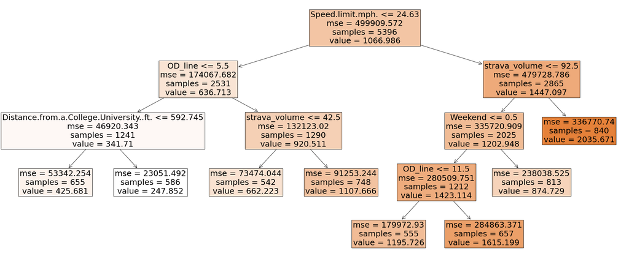

```python
# we can also visualize the Decision Tree
fig = plt.figure(figsize=(35, 15))
_ = tree.plot_tree(
    final_DT_model, feature_names=X_data.columns, filled=True, fontsize=25)
```

## Doing 10-Fold CV On the CART Model

```python
scoring = {'mean_absolute_error': MAE_SCORER,
           'mean_squared_error': MSE_SCORER,
           'r2': R2_SCORER,
           'mean_absolute_percentage_error': MAPE_SCORER}
CART_CV_scores = cross_validate(
    final_DT_model, X, Y, cv=10, scoring=scoring, return_train_score=True)
sorted(CART_CV_scores.keys())
```

```
['fit_time',
 'score_time',
 'test_mean_absolute_error',
 'test_mean_absolute_percentage_error',
 'test_mean_squared_error',
 'test_r2',
 'train_mean_absolute_error',
 'train_mean_absolute_percentage_error',
 'train_mean_squared_error',
 'train_r2']
```

```python
print(
    f"Training MAPE:  {(-CART_CV_scores['train_mean_absolute_percentage_error']).mean()}\tTesting MAPE: {(-CART_CV_scores['test_mean_absolute_percentage_error']).mean()}")
print(
    f"Training RMSE: {(np.sqrt(-CART_CV_scores['train_mean_squared_error'])).mean()}\tTesting RMSE: {(np.sqrt(-CART_CV_scores['test_mean_squared_error'])).mean()}")
print(
    f"Training MAE:  {(-CART_CV_scores['train_mean_absolute_error']).mean()}\tTesting MAE: {(-CART_CV_scores['test_mean_absolute_error']).mean()}")
print(
    f"Training R2:   {(CART_CV_scores['train_r2']).mean()}\tTesting R2: {(CART_CV_scores['test_r2']).mean()}")
```

```
Training MAPE:  50.45120716631829	Testing MAPE: 56.860441641287466
Training RMSE: 415.54404647715967	Testing RMSE: 421.73274869847194
Training MAE:  303.94497120695394	Testing MAE: 325.94563818787356
Training R2:   0.6500636511993884	Testing R2: 0.45803623657912096
```

# Using A DNN

Since this current notebook is of a large size, we have decided to run our DNN Hyperparameter search and 10-Fold CV in separate notebooks. We have included the results of these notebooks here as text:

## First we considered a DNN Hyperparameter Search on the raw data, all 45 variables.

The search (conducted in a separate notebook, due to the size of this notebook) resulted in these best hyperparameters:

```
lr: 0.006250169080446751
batch_size: 16
HL0_ac_fn: relu
HL1_ac_fn: relu
HL2_ac_fn: relu
HL3_ac_fn: relu

Sequential(
  (0): Linear(in_features=45, out_features=100, bias=True)
  (1): ReLU()
  (2): Linear(in_features=100, out_features=50, bias=True)
  (3): ReLU()
  (4): Linear(in_features=50, out_features=25, bias=True)
  (5): ReLU()
  (6): Linear(in_features=25, out_features=12, bias=True)
  (7): ReLU()
  (8): Linear(in_features=12, out_features=1, bias=True)
)
```

Further investigation into that model (1000 epochs) lead to these results:

```
------------------------------------------- TRAINING SCORES -------------------------------------------
Overall MAE: 506.3859067382813 +/- 213.8931333902926
Overall RMSE: 614.7109517364502 +/- 249.68981121865465
Overall MAPE: 105.72283459234238 +/- 106.76437929482991
Overall R2: -146.1750120282173 +/- 1050.4377217347533

------------------------------------------- TESTING SCORES -------------------------------------------
Overall MAE: 496.89939270019534 +/- 48.49974129023237
Overall RMSE: 640.2378510131836 +/- 49.66673463202634
Overall MAPE: 101.05311183166503 +/- 19.11839109918788
Overall R2: 13.97423979640007 +/- 12.406959037785937
```

Here are the 10-Fold CV results for this model:

[output not shown]

## Next we considered a DNN Hyperparameter Search on the scaled data, all 45 variables

The search resulted in these best hyperparameters:

```
lr: 0.0012782353276565707
batch_size: 16
n_layers: 5
neurons_HL1: 638
HL0_ac_fn: relu
HL1_ac_fn: relu
HL2_ac_fn: linear
HL3_ac_fn: linear
HL4_ac_fn: linear
Sequential(
    (0): Linear(in_features=45, out_features=638, bias=True)
    (1): ReLU()
    (2): Linear(in_features=638, out_features=319, bias=True)
    (3): ReLU()
    (4): Linear(in_features=319, out_features=159, bias=True)
    (5): Linear(in_features=159, out_features=79, bias=True)
    (6): Linear(in_features=79, out_features=39, bias=True)
    (7): Linear(in_features=39, out_features=1, bias=True)
)
```

Further investigation into that model (1000 epochs) lead to these results:

```
------------------------------------------- TRAINING SCORES -------------------------------------------
Overall MAE: 127.04247235107422 +/- 99.90102627944705
Overall RMSE: 175.43406332778932 +/- 154.28729810850598
Overall MAPE: 15.875287336111068 +/- 19.4009852555714
Overall R2: 69.11674812436104 +/- 80.51793512312459


------------------------------------------- TESTING SCORES -------------------------------------------
Overall MAE: 162.0754659729004 +/- 7.1560650020547785
Overall RMSE: 266.23735757446286 +/- 8.60939057357635
Overall MAPE: 21.138779476165773 +/- 1.1536040792023885
Overall R2: 85.19760499596596 +/- 1.0113892271931464
```

Here are the 10-Fold CV results for this model:

| **Fold #** | **MAPE** | **RMSE** | **MAE** | **R2** |
| --- | --- | --- | --- | --- |
| Fold 1 | 18.44/23.77 | 252.48/265.72 | 147.38/168.35 | 0.88/0.86 |
| Fold 2 | 18.67/20.34 | 254.95/228.59 | 147.41/144.99 | 0.87/0.89 |
| Fold 3 | 18.86/23.74 | 253.22/273.57 | 148.11/161.55 | 0.87/0.86 |
| Fold 4 | 18.64/30.56 | 250.02/273.43 | 145.79/159.51 | 0.88/0.85 |
| Fold 5 | 18.69/21.20 | 250.74/281.42 | 147.16/167.99 | 0.88/0.85 |
| Fold 6 | 19.07/20.14 | 256.96/257.62 | 149.88/149.70 | 0.88/0.86 |
| Fold 7 | 18.42/19.81 | 248.22/295.89 | 144.35/184.37 | 0.86/0.83 |
| Fold 8 | 18.49/22.94 | 252.00/263.93 | 146.30/156.74 | 0.87/0.85 |
| Fold 9 | 18.67/21.71 | 252.39/266.29 | 148.64/152.66 | 0.88/0.85 |
| Fold 10 | 19.16/18.98 | 255.11/245.92 | 147.07/158.77 | 0.88/0.88 |
| **Averages** | **18.71/22.32** | **252.61/265.24** | **147.21/160.46** | **0.88/0.86** |

## Lastly we considered a DNN Hyperparameter Search on the data reduced to 25 Principal Components

The search (separate notebook) resulted in these best hyperparameters:

```
lr: 0.0010009502114520618
batch_size: 16
n_layers: 3
neurons_HL1: 1024
HL0_ac_fn: relu
HL1_ac_fn: relu
HL2_ac_fn: relu
Sequential(
    (0): Linear(in_features=25, out_features=1024, bias=True)
    (1): ReLU()
    (2): Linear(in_features=1024, out_features=512, bias=True)
    (3): ReLU()
    (4): Linear(in_features=512, out_features=256, bias=True)
    (5): ReLU()
    (6): Linear(in_features=256, out_features=1, bias=True)
)
```

Further investigation into that model (1000 epochs) lead to these results:

```
------------------------------------------- TRAINING SCORES -------------------------------------------
Overall MAE: 79.71059091377258 +/- 84.49931945965058
Overall RMSE: 111.38372660827636 +/- 131.9757459665678
Overall MAPE: 9.910053818970919 +/- 15.004621771562721
Overall R2: 81.50300378203393 +/- 111.02166223520635


------------------------------------------- TESTING SCORES -------------------------------------------
Overall MAE: 173.95032133483886 +/- 8.368138305017702
Overall RMSE: 286.0597731628418 +/- 12.17003063101541
Overall MAPE: 22.35633151245117 +/- 0.932604751653328
Overall R2: 82.89831009507179 +/- 1.431324887029879
```

Here are the 10-Fold CV results for this model:

| **Fold #** | **MAPE** | **RMSE** | **MAE** | **R2** |
| --- | --- | --- | --- | --- |
| Fold 1 | 15.74/24.31 | 226.53/267.42 | 128.25/160.38 | 0.90/0.86 |
| Fold 2 | 16.50/21.60 | 235.44/210.91 | 130.66/137.39 | 0.89/0.91 |
| Fold 3 | 16.14/21.36 | 227.97/277.09 | 127.59/161.39 | 0.90/0.86 |
| Fold 4 | 16.49/25.75 | 231.13/260.84 | 130.27/156.22 | 0.90/0.86 |
| Fold 5 | 16.28/22.75 | 226.80/286.54 | 128.11/168.74 | 0.90/0.84 |
| Fold 6 | 16.61/21.46 | 230.98/256.28 | 130.55/148.91 | 0.89/0.86 |
| Fold 7 | 16.51/19.75 | 228.17/276.27 | 129.42/159.67 | 0.90/0.85 |
| Fold 8 | 16.17/22.96 | 229.13/248.21 | 129.49/145.93 | 0.90/0.87 |
| Fold 9 | 15.85/21.58 | 227.87/255.73 | 127.53/148.54 | 0.90/0.86 |
| Fold 10 | 16.49/19.51 | 232.00/241.64 | 128.88/160.91 | 0.89/0.89 |
| **Averages** | **16.28/22.11** | **229.60/258.09** | **129.08/154.81** | **0.90/0.86** |

# Using A CNN (Convolutional Neural Network)

## We Conducted A CNN Hyperparameter Search On All 45 Scaled Variables

Based on the good performance of our DNN on 45 scaled vars, we have ran a search (separate notebook) that resulted in these best hyperparameters:

```
Best Study Parameters:
    batch_size: 16
    n_hdn_layers: 4
    neurons_HL1: 714
    out_channel: 128
    kernel_size: 5
    conv_activation: linear
    dropout_prob: 0.1
    mx_pl_size: 2
    mx_pl_strides: 3
    HL0_ac_fn: relu
    HL1_ac_fn: linear
    HL2_ac_fn: relu
    HL3_ac_fn: linear
Sequential(
  (0): Unflatten(dim=1, unflattened_size=(1, 45))
  (1): Conv1d(1, 128, kernel_size=(5,), stride=(1,))
  (2): Dropout(p=0.1, inplace=False)
  (3): MaxPool1d(kernel_size=2, stride=3, padding=0, dilation=1, ceil_mode=False)
  (4): Flatten(start_dim=1, end_dim=-1)
  (5): Linear(in_features=1792, out_features=714, bias=True)
  (6): ReLU()
  (7): Linear(in_features=714, out_features=357, bias=True)
  (8): Linear(in_features=357, out_features=178, bias=True)
  (9): ReLU()
  (10): Linear(in_features=178, out_features=89, bias=True)
  (11): Linear(in_features=89, out_features=1, bias=True)
)
```

Further investigation into that model (1000 epochs) lead to these results:

```
------------------------------------------- TRAINING SCORES -------------------------------------------
Overall MAE: 127.83843072414398 +/- 90.65328560853274
Overall RMSE: 171.06993522262573 +/- 137.64985868220109
Overall MAPE: 16.579783494234086 +/- 20.826968398715486
Overall R2: 69.75038325190545 +/- 105.27761032504858


------------------------------------------- TESTING SCORES -------------------------------------------
Overall MAE: 168.9494116973877 +/- 8.022559538075681
Overall RMSE: 277.84417306518554 +/- 9.953104843194573
Overall MAPE: 22.436886066436767 +/- 1.2793881256805162
Overall R2: 83.87500293254853 +/- 1.227900348513482
```

Here are the 10-Fold CV results for this model:

| **Fold #** | **MAPE** | **RMSE** | **MAE** | **R2** |
| --- | --- | --- | --- | --- |
| Fold 1 | 18.92/22.58 | 251.08/262.30 | 148.81/167.16 | 0.87/0.86 |
| Fold 2 | 18.73/21.69 | 243.81/281.73 | 145.37/165.30 | 0.88/0.83 |
| Fold 3 | 18.73/27.40 | 247.05/317.24 | 146.91/182.97 | 0.87/0.79 |
| Fold 4 | 19.32/20.97 | 250.00/248.38 | 149.08/158.73 | 0.88/0.88 |
| Fold 5 | 19.15/28.25 | 243.86/285.90 | 147.90/167.82 | 0.89/0.85 |
| Fold 6 | 19.17/22.93 | 248.65/260.44 | 148.51/155.86 | 0.87/0.86 |
| Fold 7 | 19.22/22.18 | 248.37/253.46 | 146.97/157.43 | 0.88/0.87 |
| Fold 8 | 18.85/22.29 | 246.32/296.77 | 147.74/176.25 | 0.89/0.80 |
| Fold 9 | 19.06/18.14 | 246.24/241.79 | 145.81/149.39 | 0.89/0.88 |
| Fold 10 | 19.25/22.31 | 248.35/260.01 | 146.87/154.25 | 0.87/0.87 |
| **Averages** | **19.04/22.87** | **247.37/270.80** | **147.40/163.52** | **0.88/0.85** |

## We Conducted A CNN Hyperparameter Search On The Data Reduced To 25 Principal Components

The search resulted in these best hyperparameters:

```
Best Study Parameters:
    batch_size: 16
    n_hdn_layers: 3
    neurons_HL1: 388
    out_channel: 128
    kernel_size: 5
    conv_activation: linear
    dropout_prob: 0.1
    mx_pl_size: 2
    mx_pl_strides: 2
    HL0_ac_fn: relu
    HL1_ac_fn: relu
    HL2_ac_fn: relu
Sequential(
  (0): Unflatten(dim=1, unflattened_size=(1, 25))
  (1): Conv1d(1, 128, kernel_size=(5,), stride=(1,))
  (2): Dropout(p=0.1, inplace=False)
  (3): MaxPool1d(kernel_size=2, stride=2, padding=0, dilation=1, ceil_mode=False)
  (4): Flatten(start_dim=1, end_dim=-1)
  (5): Linear(in_features=1280, out_features=388, bias=True)
  (6): ReLU()
  (7): Linear(in_features=388, out_features=194, bias=True)
  (8): ReLU()
  (9): Linear(in_features=194, out_features=97, bias=True)
  (10): ReLU()
  (11): Linear(in_features=97, out_features=1, bias=True)
)
```

Further investigation into that model (1000 epochs) lead to these results:

```
------------------------------------------- TRAINING SCORES -------------------------------------------
Overall MAE: 97.71056816482545 +/- 81.78424977789673
Overall RMSE: 131.6625672750473 +/- 125.89378444691727
Overall MAPE: 12.892659771203995 +/- 20.992895892969372
Overall R2: 80.18670288920401 +/- 80.89358797014853


------------------------------------------- TESTING SCORES -------------------------------------------
Overall MAE: 176.57798167419435 +/- 8.175191521286836
Overall RMSE: 284.9779208984375 +/- 10.737572034407977
Overall MAPE: 22.87504454421997 +/- 0.8771065813787268
Overall R2: 83.03403191566467 +/- 1.2712884901216657
```

Here are the 10-Fold CV results for this model:

| **Fold #** | **MAPE** | **RMSE** | **MAE** | **R2** |
| --- | --- | --- | --- | --- |
| Fold 1 | 17.07/21.96 | 235.62/245.97 | 135.75/161.95 | 0.89/0.88 |
| Fold 2 | 17.68/22.00 | 232.14/285.54 | 136.62/164.97 | 0.90/0.83 |
| Fold 3 | 17.18/25.65 | 233.79/292.90 | 136.72/166.75 | 0.89/0.82 |
| Fold 4 | 17.64/22.38 | 236.92/243.70 | 135.86/159.40 | 0.89/0.88 |
| Fold 5 | 17.53/25.42 | 233.39/283.54 | 136.30/164.43 | 0.89/0.85 |
| Fold 6 | 17.59/25.67 | 235.93/260.76 | 135.92/163.63 | 0.89/0.86 |
| Fold 7 | 17.57/30.91 | 236.97/384.89 | 138.20/174.02 | 0.89/0.71 |
| Fold 8 | 17.13/24.11 | 228.63/299.39 | 133.22/180.53 | 0.90/0.80 |
| Fold 9 | 17.64/18.37 | 237.33/244.59 | 139.76/145.15 | 0.89/0.88 |
| Fold 10 | 18.13/22.29 | 237.11/264.51 | 139.43/161.43 | 0.88/0.87 |
| **Averages** | **17.52/23.87** | **234.78/280.58** | **136.78/164.23** | **0.89/0.84** |